# PROJECT : Analysis of the trip data of Ford GoBike, a bike-sharing system that covered the greater San Francisco Bay area from June 2017 to till April 2019.

## BY : Oluwadamilare Caleb Fabiyi

# INTRODUCTION

> The dataset used is the trip data of Ford GoBike, a regional public bicycle sharing system that covered the California's San Francisco Bay Area, one of the largest bike-sharing system in the US.

> This is an explanation of the insights from the dataset containing Ford GoBike's trip data covering the period from 28 June 2017 to 30 April 2019.

> Data can be downloaded [here](https://s3.amazonaws.com/baywheels-data/index.html) and data description is provided [here](https://www.lyft.com/bikes/bay-wheels/system-data) .

# INSIGHTS EXPLANATION AND VISUALIZATION

## 1) The Company has experienced Growth overtime.

**The growth of the company is evident in the fact that there has been a systematic increase in the number of trips per month except for an observed reduction in Novembers and Decembers.**

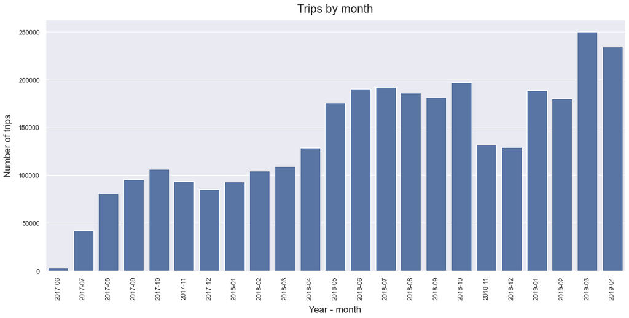

## 2) There is an observed decrease in patronage repeatedly in Novembers and Decembers.

**There is noticed repeated sudden drop that deviates from the normal trend of trips increase in number of trips in November and December which surges again in January.**

**This phenomenon should be further investigated as there are no informations to establish a reason for this sudden decrease.**

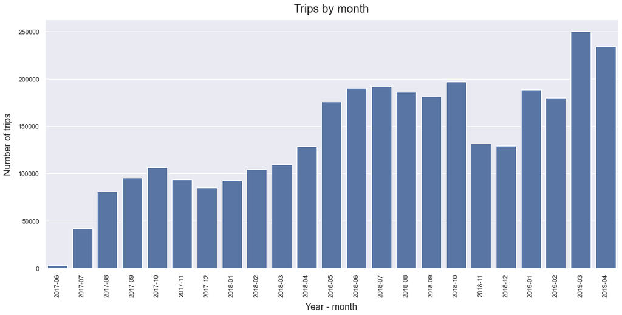

## 3) Customers( Non Subscribers ) ride more on weekends than weekdays while Subscribers ride more during workdays than weekends.

**Riders who are just casual customers and not subscribers ride more during weekend than weekdays.**

**Riders who are subscribers ride more doing workdays and ride less in weekends.**

### Casual Customers ride more on weekends

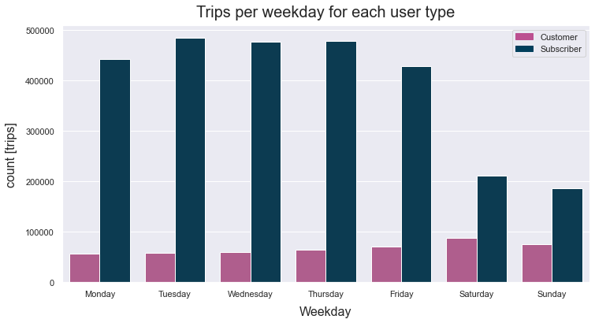

## 4) Customers( Non Subscribers ) ride for a longer duration than subscribers and there is an observed relatively more trip durations during weekends than workdays.

**Riders who are casual customers ride for longer trip duration than subscribers.**

**Riders who are casual customers ride more during weekends than workdays therefore the observed relatively more trips duration during weekends can be attributed to it.**

### Casual Customers ride for a longer time than Subscribers

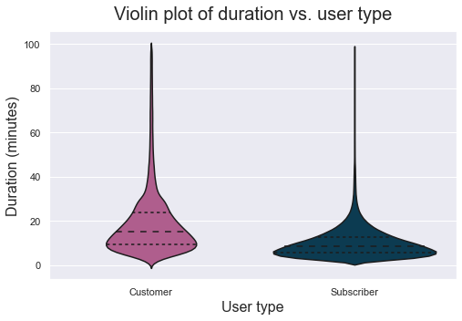

### There are longer trips during weekend than weekdays

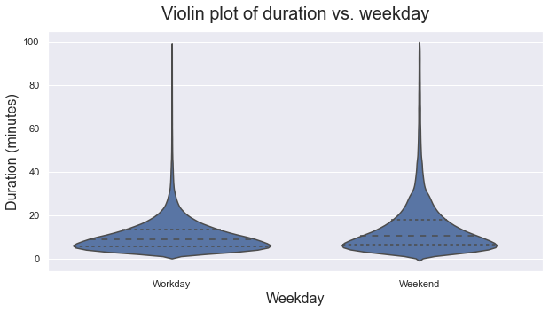

## 5) Trips peak everyday around 8a.m-9a.m and 5p.m-6p.m for both subscribers and custiomers though customers have relatively more trips than subscribers between 9a.m to 5p.m.

**It is suspected that people take bikes when going to work in the morning and when returning in the evening.**

**Customers take trips more than subscribers between 9a.m to 5p.m and considering the fact that there are aso more customers on weekend, we can suspect that most customers don't use the bikes to navigte to and from work, mostly subscribers do.**

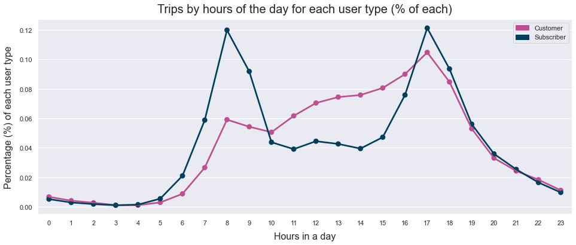

# CONCLUSION ( Insights Summary )

### 1) The Company has experienced Growth overtime

The growth of the company is evident in the fact that there has been a systematic increase in the number of trips per month except for an observed reduction in Novembers and Decembers.

### 2) There is an observed decrease in patronage repeatedly in Novembers and Decembers.

There is noticed repeated sudden drop that deviates from the normal trend of trips increase in number of trips in November and December which surges again in January.

This phenomenon should be further investigated as there are no informations to establish a reason for this sudden decrease.

### 3) Customers( Non Subscribers ) ride more on weekends than weekdays while Subscribers ride more during workdays than weekends.

Riders who are just casual customers and not subscribers ride more during weekend than weekdays.

Riders who are subscribers ride more doing workdays and ride less in weekends.

### 4) Customers( Non Subscribers ) ride for a longer duration than subscribers and there is an observed relatively more trip durations during weekends than workdays.

Riders who are casual customers ride for longer trip duration than subscribers.

Riders who are casual customers ride more during weekends than workdays therefore the observed relatively more trips duration during weekends can be attributed to it.

### 5) Trips peak everyday around 8a.m-9a.m and 5p.m-6p.m for both subscribers and custiomers though customers have relatively more trips than subscribers between 9a.m to 5p.m.

It is suspected that people take bikes when going to work in the morning and when returning in the evening.

Customers take trips more than subscribers between 9a.m to 5p.m and considering the fact that there are aso more customers on weekend, we can suspect that most customers don't use the bikes to navigte to and from work, mostly subscribers do.

# LIMITATIONS

> There is no adequate information to explore the reasons for the sudden drop in patronage in November and Decembers

> There is no adequate information tp explore reasons why casual customers prefer weekends to workdays